# Scaling Writes — Full System Design Interview Notes

This notebook covers:

- What scaling writes means
- Why writes are harder than reads
- Vertical scaling
- Write-optimized databases
- Write-path optimization
- Horizontal sharding
- Partition key selection
- Vertical partitioning
- Queues for burst handling
- Load shedding
- Batching
- Hierarchical aggregation
- Fan-in vs fan-out
- Hot keys
- Resharding
- Deep dive interview questions
- Golden interview answer

# Index

1. What is Scaling Writes?
2. Why Writes Are Harder Than Reads
3. Main Write Scaling Strategies
4. Vertical Scaling
5. Choose Write-Optimized Database
6. General DB Write Optimizations
7. Horizontal Sharding
8. Choosing a Good Partition Key
9. Important Sharding Question
10. Vertical Partitioning
11. Handling Bursts with Queues
12. Queue Tradeoffs
13. Load Shedding
14. Batching Writes
15. Application-Level Batching
16. Intermediate Batching
17. Database-Level Batching
18. Hierarchical Aggregation
19. Fan-in vs Fan-out
20. When to Use Write Scaling
21. When NOT to Use Write Scaling
22. Deep Dive Question: Resharding
23. Deep Dive Question: Hot Key Problem
24. Deep Dive Question: Split All Keys
25. Deep Dive Question: Split Hot Keys Dynamically
26. Deep Dive Question: Reader/Writer Agreement
27. Deep Dive Questions — Interview Section
28. Write Scaling Decision Table
29. Common Interview Examples
30. Golden Interview Answer

# 1. What is Scaling Writes?

**Scaling Writes** means handling high-volume write operations when a single database or server becomes the bottleneck.

Writes are operations like:

- Insert new rows
- Update counters
- Store events
- Write logs
- Track user actions
- Update locations
- Store clicks/views/likes
- Update search indexes

Examples of high-write systems:

- Likes
- Views
- Metrics
- Location updates
- Ad clicks
- Search indexing
- Live comments
- Rate limiter counters

Main goal:

```
Reduce write load per component
```

If one DB cannot handle all writes, spread, buffer, batch, or aggregate them.

⬆ Back to Index

# 2. Why Writes Are Harder Than Reads

Read scaling is easier because we can use:

- Read replicas
- Caching
- CDN

But write scaling is harder because every write changes state.

Write challenges:

- Disk I/O bottleneck
- CPU bottleneck
- Network bottleneck
- Lock contention
- Hot keys
- Bursty traffic
- Transaction conflicts
- Index update overhead
- Replication overhead

Simple example:

```
Read:
Can serve from cache

Write:
Must update source of truth
```

That is why writes need careful design.

⬆ Back to Index

# 3. Main Write Scaling Strategies

Use these four major strategies:

```
1. Vertical scaling and database choices
2. Sharding and partitioning
3. Queues and load shedding
4. Batching and hierarchical aggregation
```

Interview order:

```
First check capacity
Then optimize write path
Then shard/partition
Then queue/batch/aggregate
```

Do not overcomplicate before doing rough throughput math.

⬆ Back to Index

# 4. Vertical Scaling

Before adding complex distributed systems, check if stronger hardware solves the problem.

Writes are limited by:

```
Disk I/O
CPU
Network bandwidth
```

Improve with:

- More CPU cores
- More RAM
- Faster SSD
- Better network
- Larger DB instance
- Better storage engine configuration

This is useful as a first step.

But for very high scale, one machine eventually hits limits.

Interview line:

```
I would first estimate write QPS and compare it with DB capacity before adding sharding.
```

⬆ Back to Index

# 5. Choose Write-Optimized Database

Some databases are better for high-write workloads.

| Database Type | Good For |
| --- | --- |
| Cassandra | High write throughput |
| Time-series DB | Metrics, logs, timestamped events |
| LevelDB / LSM DB | Append-heavy workloads |
| ClickHouse | Batched analytics writes |
| Kafka | Durable event log / append-only stream |

Example:

```
Cassandra uses append-only commit logs
```

This avoids expensive random disk updates.

Tradeoff:

```
Better writes
But reads may become slower or more complex
```

Use case examples:

- Metrics → Time-series DB
- Logs/events → Kafka / LSM-based DB
- Analytics → ClickHouse
- High write key-value workloads → Cassandra

⬆ Back to Index

# 6. General DB Write Optimizations

To improve write performance:

```
Reduce indexes
Disable expensive triggers
Avoid complex constraints on hot path
Tune WAL / fsync
Batch commits
Avoid full-text indexing on hot write path
```

Important tradeoff:

```
Fewer indexes = faster writes
But slower reads
```

Every index has a write cost because it must be updated on insert/update/delete.

Example:

```
User writes one row
DB also updates 5 indexes
```

That single write becomes multiple internal writes.

⬆ Back to Index

# 7. Horizontal Sharding

If one DB cannot handle writes, split writes across multiple shards.

Example:

```
1 DB handles 1,000 writes/sec
10 shards may handle ~10,000 writes/sec
```

Architecture:

```
App
 ↓
Shard Router
 ↓
Shard 1
Shard 2
Shard 3
Shard 4
```

Each shard handles only a subset of data.

Common shard keys:

- user_id
- post_id
- order_id
- device_id
- tenant_id

Goal:

```
Evenly distribute writes across shards
```

⬆ Back to Index

# 8. Choosing a Good Partition Key

A good partition key spreads writes evenly.

Good examples:

```
hash(user_id)
hash(post_id)
hash(order_id)
```

Bad example:

```
country
```

Why country is bad:

```
China shard overloaded
New Zealand shard underused
```

Good key properties:

- High cardinality
- Even distribution
- Commonly available in queries
- Groups related data when needed
- Avoids hot partitions

Goal:

```
Flat distribution across shards
```

⬆ Back to Index

# 9. Important Sharding Question

Always ask:

```
How many shards does this request need to hit?
```

Good partitioning should:

- Spread writes evenly
- Group commonly accessed data together
- Avoid fan-out reads across all shards

Bad design:

```
Writes are distributed
But every read hits all shards
```

That creates read overhead.

Example:

```
Shard by post_id
Good for post writes

But if user profile needs all posts by user
May need many shards
```

Choose a shard key based on both:

- Write pattern
- Read pattern

⬆ Back to Index

# 10. Vertical Partitioning

Vertical partitioning splits columns/tables by access pattern.

Example: social media post.

Bad single table:

```
posts
  id
  user_id
  content
  media_urls
  like_count
  comment_count
  view_count
```

Problem:

```
Content writes
Metric updates
Analytics writes
All hit same table
```

Better design:

```
post_content
post_metrics
post_analytics
```

| Table | Access Pattern | Optimized For |
| --- | --- | --- |
| post_content | Write once, read many | Reads |
| post_metrics | High-frequency updates | Counters |
| post_analytics | Append-only events | Analytics |

This reduces contention and lets each table/database scale differently.

⬆ Back to Index

# 11. Handling Bursts with Queues

Traffic is not always steady.

Examples:

```
Black Friday → 4x order volume
New Year → 3x driver updates
Viral post → sudden like spike
```

Queue architecture:

```
App Server
   ↓
Queue
   ↓
Worker
   ↓
Database
```

The queue decouples:

```
Write acceptance
from
Write processing
```

Benefits:

- Absorbs bursts
- Smooths traffic spikes
- Protects database
- Workers can process at steady rate

Examples:

- Kafka
- SQS
- RabbitMQ
- Pub/Sub

⬆ Back to Index

# 12. Queue Tradeoffs

Queues are good for short bursts.

But queue is not a fix if DB cannot handle steady-state traffic.

Problem:

```
App writes to queue faster than DB drains it
↓
Queue grows forever
↓
Processing delay increases
```

Use queues when:

- Bursts are temporary
- Delayed writes are acceptable
- Eventual consistency is okay
- You need durability before processing

Do not use queues when:

- Immediate consistency is required
- Database is permanently underpowered
- Delay is unacceptable
- Queue backlog can grow unbounded

Interview line:

```
A queue absorbs bursts but does not solve steady-state undercapacity.
```

⬆ Back to Index

# 13. Load Shedding

Load shedding means intentionally dropping low-value writes when the system is overloaded.

Example: Uber/Strava location updates.

```
User sends location every few seconds
```

If overloaded:

```
Drop old location update
Wait for next fresher update
```

Better than queueing stale data.

Examples:

| System | Drop / Reduce |
| --- | --- |
| Uber | Old location updates |
| Strava | Frequent GPS points |
| Analytics | Impressions before clicks |
| Metrics | Low-priority events |
| Logging | Debug logs |

Key idea:

```
Keep important writes
Drop less important writes
Avoid total system failure
```

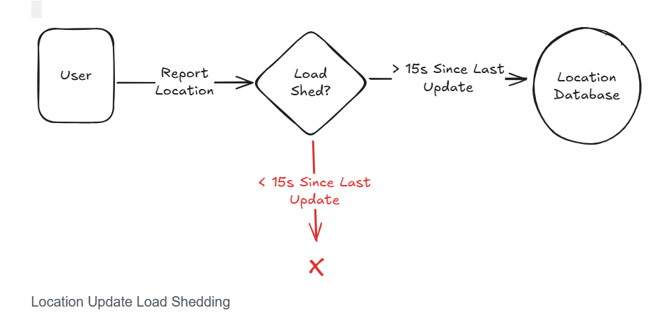

⬆ Back to Index

# 14. Batching Writes

Instead of writing one by one:

```
Write 1
Write 2
Write 3
Write 4
```

Batch:

```
Write [1, 2, 3, 4]
```

Benefits:

- Fewer network calls
- Fewer transactions
- Less disk flush overhead
- Better DB throughput
- Better compression in some databases

Good for:

- Logs
- Metrics
- Clicks
- Likes
- Views
- Bulk inserts
- Stream processing outputs

Tradeoff:

```
Batching improves throughput but adds latency
```

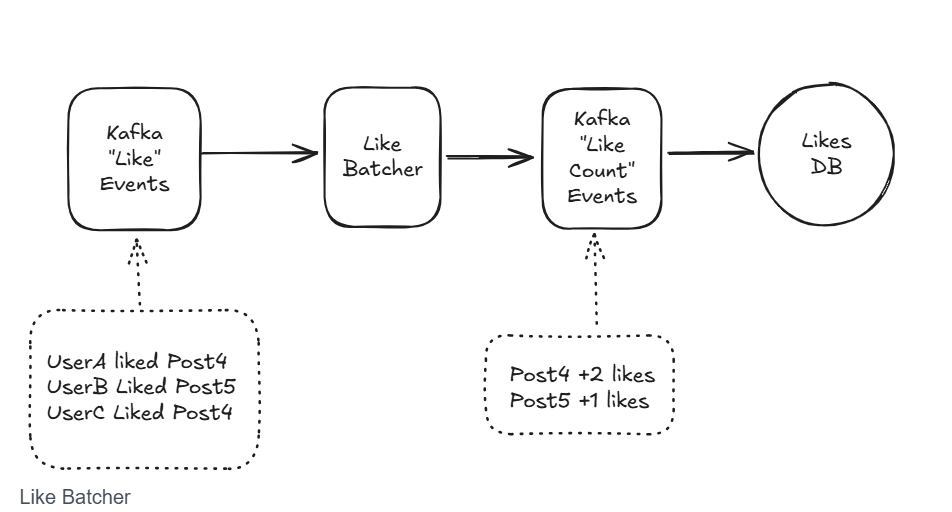

⬆ Back to Index

# 15. Application-Level Batching

Example:

```
Kafka Consumer
   ↓ reads 100 events
Process batch
   ↓
Bulk insert into DB
```

Good when Kafka/queue is source of truth.

If app crashes:

```
Re-read from Kafka
Reprocess batch
```

Be careful when app confirms a user request before batch is committed.

Risk:

```
User receives success
Service crashes before DB write
Data lost
```

So use batching only when durability and acknowledgement semantics are clear.

⬆ Back to Index

# 16. Intermediate Batching

Example: Like counter.

Without batching:

```
100 likes
↓
100 DB writes
```

With batching:

```
100 likes in 1 minute
↓
1 DB write
```

Architecture:

```
Like Events
   ↓
Like Batcher
   ↓
DB Counter Update
```

Good for:

- Likes
- Views
- Clicks
- Metrics
- Counters
- Analytics events

Important:

```
Batching helps only if many events share the same aggregation key.
```

If every key gets one event per hour, batching may not help much.

⬆ Back to Index

# 17. Database-Level Batching

Some databases batch disk writes internally.

Example:

```
Flush writes every 100ms
```

This improves throughput by reducing disk flush frequency.

Tradeoff:

- Higher throughput
- Possible durability risk depending on configuration
- More latency before data is fully durable

Use this carefully.

Interview line:

```
I prefer application/stream-level batching first, and tune DB-level batching only when necessary.
```

⬆ Back to Index

# 18. Hierarchical Aggregation

Use hierarchical aggregation when write volume is extremely high and data can be aggregated.

Example: live comments / likes during live stream.

Problem:

```
Millions of users write
Millions of users need updates
```

Naive design:

```
Every write sent to every viewer
```

Too expensive.

Better design:

```
User Events
   ↓
Write Processors
   ↓ aggregate by comment/post
Root Processor
   ↓ merge
Broadcast Nodes
   ↓
Viewers
```

Benefits:

- Reduces write volume per component
- Reduces fan-in pressure
- Reduces fan-out pressure
- Makes each layer handle manageable load

Tradeoff:

- Adds latency
- More moving parts
- Eventually consistent

⬆ Back to Index

# 19. Fan-in vs Fan-out

## Fan-in

**Fan-in** means many inputs go into one component.

Example:

```
Millions of users
   ↓
One comment processor
```

Problem:

```
One component receives too many writes
```

Fan-in bottleneck examples:

- Many users liking one viral post
- Many metrics sent to one aggregator
- Many devices sending location to one service
- Many logs sent to one collector

Solution:

- Partition by key
- Add multiple processors
- Batch writes
- Hierarchical aggregation

## Fan-out

**Fan-out** means one event must be sent to many outputs.

Example:

```
Celebrity posts once
   ↓
Send to 10M followers
```

Problem:

```
One write creates millions of downstream writes
```

Fan-out bottleneck examples:

- Celebrity news feed post
- Live stream comment broadcast
- Notification to millions of users
- Cache invalidation to many regions

Solution:

- Async fan-out workers
- Queue-based fan-out
- Pull model for celebrity posts
- Broadcast nodes
- Hierarchical distribution
- Batch notifications

## Fan-in vs Fan-out Table

| Concept | Meaning | Example | Main Problem | Solution |
| --- | --- | --- | --- | --- |
| Fan-in | Many inputs to one system | 1M likes to one post | Hot key / overloaded processor | Shard, split key, aggregate |
| Fan-out | One input to many outputs | One post to 10M followers | Too many downstream writes | Queue, batch, pull model, broadcast tree |

Interview line:

```
Fan-in overloads the receiver.
Fan-out overloads the downstream distribution path.
```

In live comments, both happen:

- Fan-in: millions of users send comments/likes
- Fan-out: updates must be shown to millions of viewers

⬆ Back to Index

# 20. When to Use Write Scaling

Use write scaling when:

- Write throughput is high
- Single DB cannot handle writes
- Traffic is bursty
- Hot keys exist
- Counters are updated frequently
- Events are append-heavy
- Many writes hit same resource
- Fan-in/fan-out is large

Common systems:

| System | Write Scaling Pattern |
| --- | --- |
| Instagram | Shard posts by user ID |
| News Feed | Handle celebrity fanout carefully |
| Search | Batch indexing writes |
| Live Comments | Hierarchical aggregation |
| Ad Click Aggregator | Queue + batch + aggregate |
| Metrics Monitoring | Time-series DB + batching |
| Rate Limiter | Distributed counters |

⬆ Back to Index

# 21. When NOT to Use Write Scaling

Do not overcomplicate when scale is small.

Before adding sharding/queues, do math:

```
How many writes/sec?
Can one DB handle it?
Is delay acceptable?
Is consistency required?
```

Each strategy has tradeoffs:

| Strategy | Tradeoff |
| --- | --- |
| Queue | Delay / eventual consistency |
| Sharding | Complex reads and rebalancing |
| Batching | Added latency |
| Load shedding | Some data is dropped |
| Write-optimized DB | Read path may be worse |

Interview line:

```
I would not add sharding or queues unless the write volume actually requires it.
```

⬆ Back to Index

# 22. Deep Dive Question: Resharding

Question:

```
Started with 8 shards.
Need 16 shards.
How do you migrate without downtime?
```

Naive approach:

```
Take system offline
Rehash all data
Move data
Bring system back
```

Bad because it causes downtime.

Production approach:

```
Gradual migration
Dual writes
Read preference to new shard
Backfill old data
Cut over
```

Resharding flow:

```
1. Add new shards
2. Start dual-writing to old and new shards
3. Backfill existing data to new shards
4. Read from new shard when available
5. Verify consistency
6. Stop writing to old shard
7. Decommission old mapping
```

Key idea:

```
Maintain availability during migration
```

⬆ Back to Index

# 23. Deep Dive Question: Hot Key Problem

Question:

```
What happens when one key becomes too popular for one shard?
```

Example:

```
One viral tweet gets 100,000 likes/sec
```

Even if tweets are spread across shards, this one tweet becomes hot.

Problem:

```
All writes for tweet123 go to same key/shard
```

One shard cannot handle all writes.

Solutions:

- Split all keys
- Split hot keys dynamically
- Batch counter updates
- Use approximate counters
- Use hierarchical aggregation

Important:

```
This works best for aggregatable data like likes/views/clicks.
```

It does not work well for atomic data like:

- User profile
- Payment state
- Order state

⬆ Back to Index

# 24. Deep Dive Question: Split All Keys

Split every key into `k` subkeys.

Example:

```
post1Likes-0
post1Likes-1
post1Likes-2
...
post1Likes-k-1
```

Writes are distributed across subkeys.

To read total likes:

```
Read all subkeys
Sum counts
```

Pros:

- Simple
- Reduces write load per key
- Easy to reason about

Cons:

- More storage
- Read amplification
- More complex aggregation
- All keys pay the cost even if not hot

Use when:

- Many keys can become hot
- Read amplification is acceptable
- Counters are aggregatable

⬆ Back to Index

# 25. Deep Dive Question: Split Hot Keys Dynamically

Instead of splitting all keys, split only hot keys.

Example:

```
Normal post → one key
Viral post → 100 subkeys
```

For viral tweet:

```
tweet123:likes:0
tweet123:likes:1
...
tweet123:likes:99
```

Each handles part of the write traffic.

Read total:

```
Sum all subkeys
```

Pros:

- Efficient for normal keys
- Handles extreme hot keys
- Less storage than splitting all keys

Cons:

- More complex
- Need hot-key detection
- Readers and writers must know split state

Works well for:

- Likes
- Views
- Clicks
- Counters

Does not work well for:

- Atomic user profile
- Payment status
- Order state

⬆ Back to Index

# 26. Deep Dive Question: Reader/Writer Agreement

Question:

```
If writers split a hot key, how do readers know where to read?
```

Problem:

```
Writers write to subkeys
Readers only read original key
```

Result:

```
Incorrect count
```

Solutions:

### Simple solution

Readers always check possible subkeys.

```
Read tweet123:likes
Read tweet123:likes:0
Read tweet123:likes:1
...
Sum all
```

Pros:

- Simple
- Robust

Cons:

- Read amplification

### Complex solution

Writers announce split to readers before using subkeys.

Pros:

- More efficient reads

Cons:

- Harder coordination
- More operational complexity

Most production systems prefer simpler approach unless scale forces optimization.

⬆ Back to Index

# 27. Deep Dive Questions — Interview Section

Use this section for interview preparation.

## Q1. How do you scale writes beyond one database?

Answer:

```
First optimize the write path and database.
Then shard by a high-cardinality key.
For bursts, use queue.
For counters/events, batch and aggregate.
```

## Q2. How do you choose a shard key?

Answer:

```
Choose high-cardinality key with even distribution and good query locality.
Examples: user_id, post_id, order_id.
Avoid low-cardinality keys like country/status.
```

## Q3. What if one shard becomes hot?

Answer:

```
Identify hot key or bad partition key.
If bad key, repartition.
If one viral key, split hot key into subkeys and aggregate on read.
```

## Q4. How do you handle bursty writes?

Answer:

```
Use queue if delay is acceptable.
Use load shedding if some writes are low value.
Autoscaling can help but is not instant.
```

## Q5. When should you not use a queue?

Answer:

```
When writes need immediate consistency,
when delay is unacceptable,
or when steady-state write rate exceeds DB capacity.
A queue only buffers; it does not solve permanent undercapacity.
```

## Q6. How do you prevent queue backlog from growing forever?

Answer:

```
Monitor queue depth and processing latency.
Autoscale workers.
Add backpressure.
Shed low-priority writes.
Increase DB capacity.
```

## Q7. How do you scale counters like likes/views?

Answer:

```
Do not update one DB row for every event.
Use batching, sharded counters, hot-key splitting, or hierarchical aggregation.
```

## Q8. How do you handle resharding?

Answer:

```
Add new shards, dual-write to old and new locations,
backfill old data, read from new when available,
verify, then cut over.
```

## Q9. What is fan-in?

Answer:

```
Many writers send data to one component/key.
Example: 1M users like one viral post.
Problem: receiver/key becomes bottleneck.
```

## Q10. What is fan-out?

Answer:

```
One event creates many downstream writes.
Example: celebrity post delivered to 10M followers.
Problem: distribution path becomes bottleneck.
```

## Q11. How do you solve fan-in/fan-out in live comments?

Answer:

```
Use hierarchical aggregation.
Multiple write processors aggregate incoming events.
Root processor merges.
Broadcast nodes distribute updates to viewers.
```

## Q12. What is the tradeoff of batching?

Answer:

```
Batching improves throughput by reducing per-write overhead,
but adds latency and may complicate failure handling.
```

## Q13. What is load shedding?

Answer:

```
When overloaded, reject/drop low-value writes to protect the system.
Example: drop stale location updates or debug logs.
```

## Q14. How do write-optimized databases differ?

Answer:

```
They optimize append-heavy writes using commit logs or LSM structures,
but may trade off read performance or query flexibility.
```

## Q15. What is the golden write-scaling principle?

Answer:

```
Reduce throughput per component by spreading, buffering, batching, aggregating, or dropping low-value writes.
```

⬆ Back to Index

# 28. Write Scaling Decision Table

| Problem | Solution |
| --- | --- |
| Single DB write limit | Vertical scale / write-optimized DB |
| Write volume too high | Sharding |
| Uneven shard load | Better partition key |
| Bursty traffic | Queue |
| Overload with disposable writes | Load shedding |
| Many small writes | Batching |
| Counter updates | Batch aggregation |
| Massive fan-in | Partition + aggregate |
| Massive fan-out | Queue + broadcast tree |
| Hot key | Split key |
| Need more shards | Gradual resharding |
| Read path hurt by sharding | Choose better data layout |
| High analytics writes | Time-series DB / ClickHouse |
| Search indexing writes | Queue + batch indexer |

⬆ Back to Index

# 29. Common Interview Examples

| System | Write Scaling Approach |
| --- | --- |
| Instagram | Shard posts by user ID, separate metrics |
| Twitter/X | Handle celebrity fanout, hot tweet counters |
| News Feed | Fanout-on-write for normal users, pull model for celebrities |
| Search | Queue + batch indexing |
| Live Comments | Hierarchical aggregation |
| Ad Click Aggregator | Queue + batch + aggregate |
| Metrics Monitoring | Time-series DB + batching |
| Rate Limiter | Distributed counters |
| Uber Location | Load shedding + latest location wins |
| Strava GPS | Drop/merge frequent GPS points |
| YouTube Metrics | Batch views/likes, aggregate counters |

⬆ Back to Index

# 30. Golden Interview Answer

> I would scale writes in stages. First, I would estimate write throughput and check whether the existing database and hardware can handle it. Then I would optimize the write path by reducing unnecessary indexes, triggers, and expensive constraints. If the workload is truly write-heavy, I would choose a write-optimized datastore like Cassandra, a time-series database, Kafka, or ClickHouse depending on the use case. If one node is still not enough, I would shard by a high-cardinality key like user ID or post ID to distribute writes evenly. For bursty traffic, I would use queues when eventual consistency is acceptable, or load shedding for low-value writes like stale location updates. For counters, analytics, likes, views, and metrics, I would batch writes and use hierarchical aggregation to reduce write pressure. I would also handle deep dives like resharding and hot keys using dual writes, gradual migration, key splitting, and reader/writer agreement.

⬆ Back to Index

# Extra: Like Batcher Pseudocode

This is interview-style Python pseudocode to show how batching reduces writes.

⬆ Back to Index

```python
from collections import Counter
import time

class LikeBatcher:
    def __init__(self, db, flush_interval_seconds=60):
        self.db = db
        self.flush_interval_seconds = flush_interval_seconds
        self.buffer = Counter()

    def add_like(self, post_id):
        self.buffer[post_id] += 1

    def flush(self):
        # Instead of 100 writes for 100 likes,
        # do one aggregated write per post.
        for post_id, count_delta in self.buffer.items():
            self.db.execute(
                "UPDATE post_metrics SET like_count = like_count + %s WHERE post_id = %s",
                [count_delta, post_id]
            )

        self.buffer.clear()

    def run(self):
        while True:
            time.sleep(self.flush_interval_seconds)
            self.flush()
```